# Análise de séries temporais: com aplicações no R

Outubro de 2022

## Modelos ARIMA

## Modelos ARIMA

- A regressão clássica muitas vezes é insuficiente para explicar todas as dinâmicas de uma série temporal.
- Por exemplo, o ACF dos resíduos da regressão linear simples ajustada aos dados dos casos AIDS de (ver Exemplo: Eliminando tendência da série dos casos de AIDS) revela uma estrutura adicional nos dados que a regressão não capturou.
- Além disso, a introdução da correlação como um fenômeno que pode ser gerado através de relações lineares retardadas leva a pensarmos nos modelos autorregressivos (AR) e médias móveis (MA).
- Muitas vezes, esses modelos são combinados para formar os modelos autorregressivos e de médias móveis (ARMA).

## Modelos ARIMA

- A adição de modelos não-estacionários ao ARMA conduz aos modelos autorregressivos, integrados e de médias móveis (ARIMA) popularizados em Box e Jenkins (1970).
- Dados sazonais, por sua vez, nos conduz aos modelos autorregressivos, integrados e de médias móveis sazonais (SARIMA).
- O método Box–Jenkins para identificar modelos plausíveis, técnicas de estimação de parâmetros e previsão são discutidos nesta seção.

## Modelos ARMA

- Como já vimos, os modelos autorregressivos (AR) baseiam-se na ideia de que o valor atual de série, \(x_t\), pode ser explicado por \(p\) valores passados, \(x_{t-1}, x_{t-2},\dots, x_{t-p}\).
- Lembrem-se do Exemplo: Autorregressão em que os dados foram gerados pelo modelo \[ x_t = x_{t-1} - 0.9 x_{t-2} + w_t, \] em que \(w_t\) é ruído gaussiano com \(\sigma_w^2 = 1\).
- Naquele exemplo, o valor atual, \(x_t\), é uma função linear particular de valores passados, \(x_{t-1}\) e \(x_{t-2}\).

## Modelos ARMA

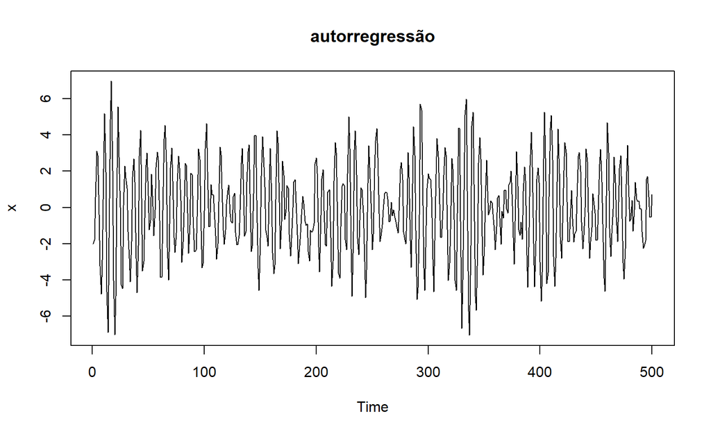

## Modelos ARMA

- Lá, a previsão de valores futuros da série é obtida através do modelo \[x^n_{n+1} = x_n - 0.9 x_{n-1},\] onde a quantidade no lado esquerdo denota a previsão no próximo período \(n+1\) com base nos dados observados, \(x_1, x_2,\dots, x_n\).

## Modelos ARMA

- Mais adiante, teremos uma noção mais precisa em nossa discussão sobre previsão.

**Definição:** Um **modelo autorregressivo** de ordem \(p\), abreviadamente AR(\(p\)), é dado na forma \[ x_t = \phi_1 x_{t-1} + \phi_2 x_{t-2} + \cdots + \phi_p x_{t-p} + w_t, \] com \(x_t\) estacionária, e \(\phi_1, \phi_2, \dots, \phi_p\) constantes diferentes de zero.

- Notem que esta equação é semelhante ao modelo de regressão da seção anterior e, portanto, recebe o nome de autorregressão.

### **Exemplo: Processo AR(1)**

- Consideremos os dois processos AR(1) \[ x_t = 0.9 x_{t-1} + w_t \qquad {\rm e} \qquad x_t = -0.9 x_{t-1} + w_t, \] com \(\sigma_w^2 = 1\), em ambos os casos.
- As duas figuras a seguir mostram o gráfico dos dois processos AR(1), um com \(\phi = 0.9\) e um com \(\phi = -0.9\), respectivamente.

### **Exemplo: Processo AR(1)**

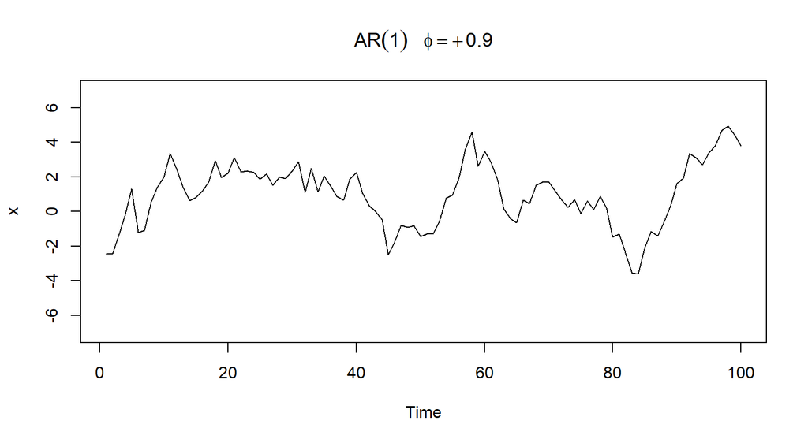

### **Exemplo: Processo AR(1)**

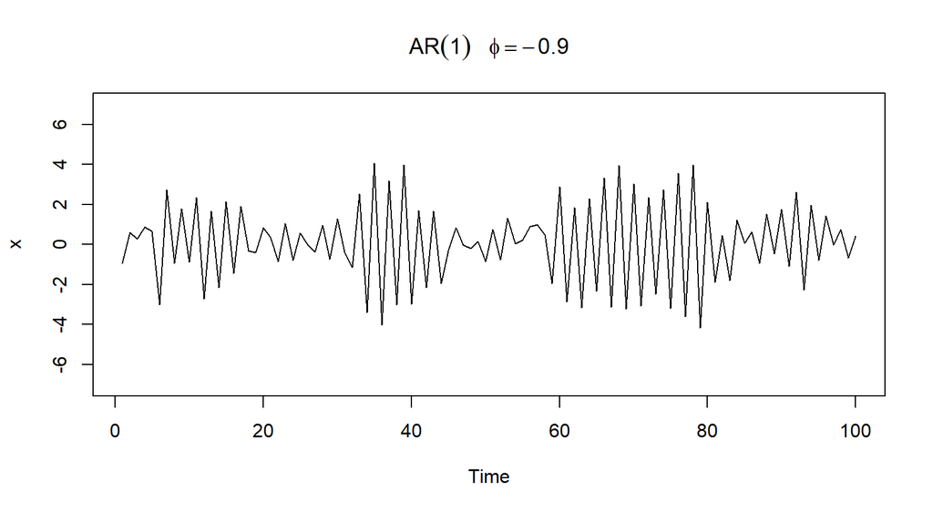

### **Exemplo: Processo AR(1)**

- No primeiro gráfico, \(\rho(h) = 0.9^h\), as observações próximas no tempo estão positivamente correlacionadas entre si.
- Este resultado significa que observações em pontos de tempo contíguos tendem a ter valores próximos.
- Por outro lado, quando \(\phi = -0.9\), de modo que \(\rho(h) = -0.9^h\), significa que observações em pontos de tempo contíguos são negativamente correlacionadas.
- O segundo processo está representado no segundo gráfico.
- No segundo processo, se uma observação \(x_t\) é positiva, a observação seguinte, \(x_{t+1}\), é tipicamente negativa e a observação \(x_{t+2}\) é tipicamente positiva.

### **Exemplo: Processo AR(1)**

- Isto torna o processo mais agitado (como se diz na economia, nervoso).
- O seguinte código no R foi usado para obter as figuras dos dois processos AR(1):

```r
plot(arima.sim(list(order=c(1,0,0), ar=0.9), n=100), ylim=c(-7,7))
plot(arima.sim(list(order=c(1,0,0), ar=-0.9), n=100), ylim=c(-7,7))
```

**Observação**: A função `arima.sim` é útil para simular um processo de um modelo ARIMA(\(p,d,q\)) e o argumento `order` indica a ordem do processo. Neste exemplo, `order=c(1,0,0)`, tem-se \(p=1, d=0, q=0\), ou seja, um AR(1).

## Modelos ARMA

- De modo alternativo, no modelo de média móvel de ordem \(q\), ou simplesmente MA(\(q\)), os dados observados são dados pela combinação linear do ruído branco \(w_t\).

**Definição:** O **modelo de média móvel** de ordem \(q\), MA(\(q\)), é definido por \[ x_t = w_t + \theta_1 w_{t-1} + \theta_2 w_{t-2} + \cdots + \theta_q w_{t-q}, \] com \(q\) defasagens na média móvel e \(\theta_1, \theta_2,\dots, \theta_q\) são parâmetros não nulos.

## Modelos ARMA

- Agora, vamos aos modelos autorregressivos de médias móveis (ARMA) para séries temporais estacionárias.

**Definição:** Uma série temporal é ARMA(\(p,q\)) se ela é estacionária e \[ \begin{aligned} x_t =\ &\phi_1 x_{t-1} + \phi_2 x_{t-2} + \cdots + \phi_p x_{t-p} + w_t \\[1mm] &+ \theta_1 w_{t-1} + \theta_2 w_{t-2} + \cdots + \theta_q w_{t-q}, \end{aligned} \] com \(\phi_p \neq 0, \theta_q \neq 0\), e \(\sigma_w^2 > 0\).

- Os parâmetros \(p\) e \(q\) são chamados de ordem autorregressiva e ordem média móvel, respectivamente.

## Modelos ARMA

**Atenção!**

- O modelo ARMA pode ser visto como uma regressão de \(x_t\) nos valores passados \(x_{t-1},\dots, x_{t-p}\), com erros correlacionados.
- Isto é,

\[ x_t = \phi_1 x_{t-1} + \phi_2 x_{t-2} + \cdots + \phi_p x_{t-p} + \epsilon_t, \] em que \(\epsilon_t = w_t + \theta_1 w_{t-1} + \theta_2 w_{t-2} + \cdots + \theta_q w_{t-q}.\)

## Função de autocorrelação parcial

- Os processos AR(\(p\)), MA(\(q\)) e ARMA(\(p,q\)) apresentam ACF com características especiais (Morettin e Toloi, 2006):
  1. um processo AR(\(p\)) tem ACF que decai de acordo com exponenciais e/ou senóides amortecidas, infinita em extensão;
  2. um processo MA(\(q\)) tem ACF finita, no sentido que ela apresenta um corte após a defasagem \(q\). Assim, o ACF fornece informação sobre a ordem da dependência quando trata-se de um processo de média móvel;
  3. um processo ARMA(\(p,q\)) tem ACF infinita em extensão, a qual decai de acordo com exponenciais e/ou senóides amortecidas após a defasagem \(q-p\).

## Função de autocorrelação parcial

- Se o processo é ARMA ou AR, a ACF é menos útil sobre as ordens de dependência.
- Assim, Box, Jenkins e Reinsel (1994) propõem a utilizacao de um outro instrumento para facilitar esta identificação: a *função de autocorrelação parcial* (PACF).<sup>1</sup>
- A ideia é fornecer uma função para os modelos AR que se comporte como o ACF nos modelos MA.

## Função de autocorrelação parcial

**Definição:** A função de autocorrelação parcial (PACF) de um processo estacionário, \(x_t\), denotado por \(\phi_{hh}\), para \(h=1, 2,\dots\), é \[ \phi_{11} = {\rm corr}(x_{t+1}, x_t) = \rho(1) \] e \[ \phi_{hh} = {\rm corr}(x_{t+h} - \widehat{x}_{t+h} , x_t - \widehat{x}_t), \qquad h \geqslant 2, \] em que \(\widehat{x}_t\) é a regressão de \(x_t\) em \(\{x_1, x_2,\dots, x_{h-1}\}\) e \(\widehat{x}_{t+h}\) é a regressão de \(x_{t+h}\) em \(\{x_1, x_2,\dots, x_{h-1}\}\).

- Assim, a PACF, \(\phi_{hh}\), é a correlação entre \(x_{t+h}\) e \(x_t\) com a dependência linear removida.

## Função de autocorrelação parcial

- Obviamente, programas estatísticos já possuem a função para obter a PACF implementada e não será necessário obter as regressões citadas.
- No `R`, por exemplo:

```
pacf {stats}
Pacf {forecast}
acf2 {astsa}
plot.pacf {ares}
```

- Função e respectivo pacote do `R`.

## Função de autocorrelação parcial

- É possível demonstrar que, para os processos apresentados aqui:
  1. um processo AR(\(p\)) tem PACF \(\phi_{hh} \neq 0\), para \(h \leqslant p\) e \(\phi_{hh} = 0\), para \(h > p\);
  2. um processo MA(\(q\)) tem PACF com comportamento similar à ACF de um processo AR(\(p\)), i.e., denominada por exponenciais e/ou senóides amortecidas;
  3. um processo ARMA(\(p,q\)) tem PACF que se comporta como a PACF de um processo MA.

## Função de autocorrelação parcial

- Alguns autores apresentam procedimentos para identificação das ordens \(p\) e \(q\) do modelo ARMA, a partir dos gráficos ACF e PACF, como resumidos na tabela a seguir.

  | Função | AR(\(p\)) | MA(\(q\)) | ARMA(\(p,q\)) |
  | --- | --- | --- | --- |
  | ACF | Decaimento gradativo | Decaimento brusco após defasagem \(q\) | Decaimento gradativo após a defasagem \(q-p\) |
  | PACF | Decaimento brusco após defasagem \(p\) | Decaimento gradativo | Decaimento gradativo após a defasagem \(p-q\) |

## Função de autocorrelação parcial

“*Essas observações serão úteis no procedimento de identificação do modelo aos dados observados; calculando-se as estimativas das funções de autocorrelações (ACF e PACF), que acreditamos reproduzir adequadamente as verdadeiras funções de autocorrelações desconhecidas e comparando seu comportamento com o descrito acima. Para cada modelo, tentaremos escolher um (ou mais) modelo(s) que descreva(m) o processo*” (Morettin e Toloi, 2006).

### **Exemplo: PACF de um AR(2)**

- Considerem o modelo AR(2) \[ x_t = 1.5 x_{t-1} -0.75 x_{t-2} + w_t, \] e a ACF e a PACF para 24 defasagens abaixo.

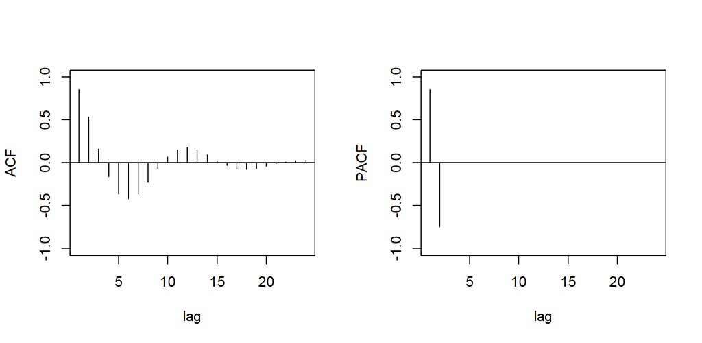

### **Exemplo: PACF de um AR(2)**

- Os comando para reproduzir esta figura no `R` são:

```r
ACF = ARMAacf(ar=c(1.5,-0.75), ma=0, 24)[-1]
PACF = ARMAacf(ar=c(1.5,-0.75), ma=0, 24, pacf=TRUE)
par(mfrow=c(1,2))
plot(ACF, type="h", xlab="lag", ylim=c(-1,1))
abline(h=0)
plot(PACF, type="h", xlab="lag", ylim=c(-1,1))
abline(h=0)
```

### **Exemplo: Análise da série de mortalidade cardiovascular**

- Consideremos o problema da modelagem mortalidade cardiovascular na figura abaixo.

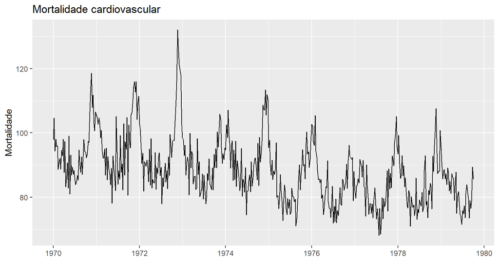

### **Exemplo: Análise de mortalidade cardiovascular**

- Usamos a função `acf2` do pacote `astsa` para imprimir os valores e plotar a ACF e a PACF amostrais.

```r
library(astsa)
acf2(cmort, 104) # computa os valores e o gráfico
```

### **Exemplo: Análise da série de mortalidade cardiovascular**

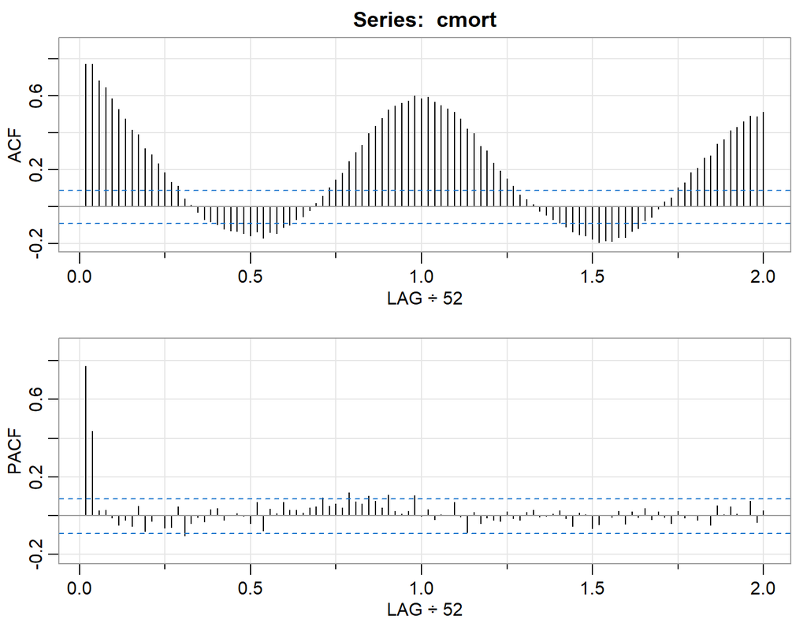

```
##      [,1] [,2] [,3] [,4]  [,5]  [,6]  [,7]  [,8] [,9] [,10] [,11] [,12] [,13]
## ACF  0.77 0.77 0.68 0.65  0.58  0.53  0.48  0.41 0.39  0.32  0.28  0.23  0.18
## PACF 0.77 0.44 0.03 0.03 -0.01 -0.05 -0.02 -0.05 0.05 -0.08 -0.03  0.00 -0.06
##      [,14] [,15] [,16] [,17] [,18] [,19] [,20] [,21] [,22] [,23] [,24] [,25]
## ACF   0.13  0.11  0.04  0.01 -0.03 -0.07 -0.08 -0.10 -0.12 -0.13 -0.13 -0.15
## PACF -0.06  0.05 -0.10 -0.04 -0.01 -0.03  0.03  0.04 -0.02  0.00  0.01  0.00
##      [,26] [,27] [,28] [,29] [,30] [,31] [,32] [,33] [,34] [,35] [,36] [,37]
## ACF  -0.16 -0.14 -0.17 -0.14 -0.15 -0.11 -0.10 -0.07 -0.06 -0.02  0.02  0.06
## PACF -0.04  0.07 -0.08  0.03  0.01  0.07  0.03  0.03  0.01  0.04  0.05  0.09
##      [,38] [,39] [,40] [,41] [,42] [,43] [,44] [,45] [,46] [,47] [,48] [,49]
## ACF   0.10  0.14  0.18  0.24  0.29  0.33   0.4  0.44  0.48  0.53  0.55  0.56
## PACF  0.05  0.06  0.04  0.12  0.07  0.06   0.1  0.08  0.04  0.11  0.02  0.01
##      [,50] [,51] [,52] [,53] [,54] [,55] [,56] [,57] [,58] [,59] [,60] [,61]
## ACF   0.57   0.6  0.58  0.59  0.57  0.55  0.53  0.51  0.48  0.42  0.39  0.33
## PACF  0.02   0.1  0.00  0.03 -0.02  0.01  0.00  0.07 -0.01 -0.09  0.02 -0.04
##      [,62] [,63] [,64] [,65] [,66] [,67] [,68] [,69] [,70] [,71] [,72] [,73]
## ACF   0.30  0.23  0.19  0.15  0.11  0.06  0.04  0.01 -0.03 -0.05 -0.07 -0.09
## PACF -0.01 -0.02 -0.03  0.02 -0.01 -0.02  0.02  0.03  0.00  0.00  0.01  0.03
##      [,74] [,75] [,76] [,77] [,78] [,79] [,80] [,81] [,82] [,83] [,84] [,85]
## ACF  -0.11 -0.14 -0.15 -0.16 -0.18 -0.19 -0.19 -0.19 -0.17 -0.17 -0.13 -0.12
## PACF -0.01 -0.05  0.02  0.00 -0.07 -0.04  0.00 -0.01  0.02 -0.04  0.02 -0.01
##      [,86] [,87] [,88] [,89] [,90] [,91] [,92] [,93] [,94] [,95] [,96] [,97]
## ACF  -0.08 -0.06 -0.01  0.03  0.05  0.10  0.13  0.18  0.21  0.26  0.28  0.34
## PACF  0.04 -0.02  0.02 -0.01 -0.04  0.02 -0.01  0.00 -0.02  0.00 -0.05  0.05
##      [,98] [,99] [,100] [,101] [,102] [,103] [,104]
## ACF   0.36  0.41   0.43   0.46   0.49   0.49   0.51
## PACF  0.01  0.05   0.01   0.00   0.08  -0.03   0.03
```

### **Exemplo: Análise da série de mortalidade cardiovascular**

- A ACF e a PACF estimadas para a série de mortalidade cardiovascular são consistentes com o comportamento de um AR(2).
  - O ACF tem ciclos (senóides) que correspondem aproximadamente a um período de 12 meses;
  - O PACF tem valores grandes para \(h = 1\) e \(h = 2\) e próximos de zero para defasagens superiores.
- Pela tabela de identificação da ordem do modelo, os resultados sugerem um AR(2) como candidato ao ajuste da série de mortalidade cardiovascular.

## Estimação

- Inicialmente, vamos assumir que temos um processo ARMA(\(p,q\)) com parâmetros de ordem \(p\) e \(q\) conhecidos.
- Discutiremos o problema de identificar \(p\) e \(q\) mais adiante.
- Então, nosso objetivo é estimar os parâmetros, \(\phi_1,\dots, \phi_p, \theta_1,\dots, \theta_q\) e \(\sigma_w^2\).
- Começamos com a estimação via **método dos momentos**.
- A ideia destes estimadores é a substituir os parâmetros populacionais pelos momentos amostrais e depois resolver as equações resultantes em termos deste momentos amostrais.

## Estimação

- Todos nós já sabemos que o método dos momentos pode produzir bons estimadores, mas, às vezes leva a estimadores não-eficientes.
- Consideramos primeiro o caso em que o método leva a estimadores eficientes, ou seja, nos modelos AR(\(p\)),

\[ x_t = \phi_1 x_{t-1} + \phi_2 x_{t-2} + \cdots + \phi_p x_{t-p} + w_t. \]

- Os estimadores que atuam desta forma nos modelos AR são chamados de **estimadores Yule-Walker**.

### **Exemplo: Estimação Yule-Walker para AR(2)**

- Os dados considerados aqui são de uma série simulada com \(n=144\) a partir do modelo AR(2) \[x_t = 1.5 x_{t-1} - 0.75 x_{t-2} + w_t,\] com \(w_t \sim {\rm N}(0,1)\).
- Para gerar este AR(2) e plotar o gráfico no `R`, usem:

```r
set.seed(8675309)   # define o valor da semente
ar2 = arima.sim(list(order=c(2,0,0), ar=c(1.5,-.75)), n = 144)
plot(ar2, axes=FALSE, xlab="Time")
axis(2)
axis(1, at=seq(0,144,by=12))
box()
abline(v=seq(0,144,by=12), lty=2)
```

### **Exemplo: Estimação Yule-Walker para AR(2)**

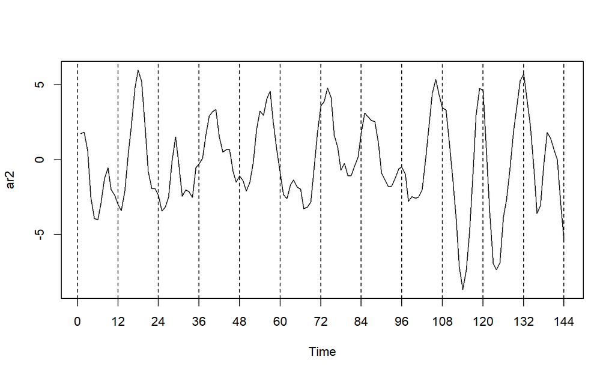

### **Exemplo: Estimação Yule-Walker para AR(2)**

- Compare estimativas \(\times\) verdadeiros valores dos parâmetros.

\[\phi_1=1.5\ {\rm e}\ \phi_2=-0.75\]

- Para a estimação Yule-Walker dos parâmetros, use

```r
ar.yw(ar2, order=2)
```

```
##
## Call:
## ar.yw.default(x = ar2, order.max = 2)
##
## Coefficients:
##       1        2
##  1.4379  -0.7051
##
## Order selected 2  sigma^2 estimated as  1.327
```

### **Exemplo: Estimação Yule-Walker para a série de mortalidade cardiovascular**

- No Ex: Análise da série de mortalidade cardiovascular os resultados sugerem um AR(2) para esta série.
- O ajuste Yule-Walker do AR(2) no R:

```r
cmort.yw = ar.yw(cmort, order=2)
cmort.yw$x.mean      # média estimada
cmort.yw$ar          # parâmetros estimados
# cmort.yw$var.pred  # variância estimada do erro
```

```
## [1] 88.69888
```

```
## [1] 0.4339481 0.4375768
```

## Estimação

**Atenção!**

- Para modelos AR(\(p\)), os estimadores Yule-Walker são estimadores eficientes, mas isso não é verdade para modelos MA(\(q\)) ou ARMA(\(p,q\)).
- Os modelos AR(\(p\)) são modelos lineares nos parâmetros, e os estimadores Yule-Walker são essencialmente estimadores de mínimos quadrados.
- MA e ARMA são modelos não-lineares, portanto esta técnica não fornece estimadores eficientes.
- O método de estimação mais utilizado nestes modelos é a **estimação de máxima verossimilhança** (EMV).
- A EMV consiste em determinar os valores dos parâmetros que têm maior probabilidade de ter produzido as observações.

### **Exemplo: EMV para a série de mortalidade cardiovascular**

- Em exemplo anterior, nós ajustamos um modelo AR(2) para a série de mortalidade cardiovascular usando Yule-Walker.
- Agora, vamos usar o R para ajustar um modelo AR(2) através da EMV para a série de mortalidade cardiovascular.
- A EMV no `R` pode ser realizada com o código:

```r
cmort.mle = ar.mle(cmort, order=2)
cmort.mle$x.mean     # média estimada
cmort.mle$ar         # parâmetros estimados
# cmort.mle$var.pred # variância estimada do erro
```

```
## [1] 88.6993
```

```
## [1] 0.4300667 0.4424522
```

### **Exemplo: Previsão da série de mortalidade cardiovascular**

- Neste exemplo, vamos ilustrar o conceito de previsão em séries temporais.
- O objetivo é prever valores futuros de uma série, \(x_{n+m}, t = 1, 2,\dots\), com base nos dados observados até o presente, \(x_1,\dots, x_n,\).
- Nos dois exemplos anteriores, ajustamos modelos AR(2) à série de mortalidade cardiovascular.
- A figura a seguir mostra o resultado da previsão para a série de mortalidade cardiovascular no horizonte de 52 semanas, \(t = 1, 2,\dots, 52\).

### **Exemplo: Previsão da série de mortalidade cardiovascular**

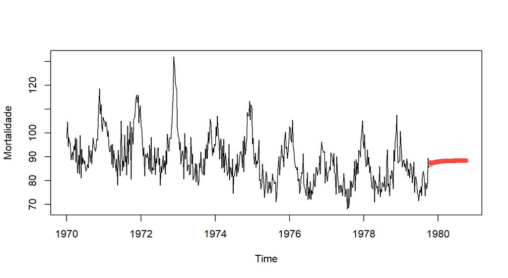

```r
ar.cmort = ar.ols(cmort, order=2, demean=FALSE, intercept=TRUE)
prev = predict(ar.cmort, n.ahead=52)$pred
ts.plot(cmort, prev, col=1:2,  ylab="Mortalidade")
lines(prev, type="p", col=2)
```

## Modelos integrados

- Para entender modelos integrados, vamos considerar o processo passeio aleatório,

\[ x_t = x_{t-1} + w_t. \]

- Tomando a primeira diferença deste processo, obtemos

\[ \begin{aligned} \nabla x_t &= x_t - x_{t-1}\\[1mm] &= (x_{t-1} + w_t) - x_{t-1}\\[1mm] &= w_t, \end{aligned} \] que é um processo ruído branco, logo, estacionário.

## Modelos integrados

- Em muitas situações, as séries temporais podem ser pensadas como sendo compostas por dois componentes:
  - um componente tendência não-estacionário; e
  - um componente estacionário de média zero.
- Como no Exemplo: Eliminando tendência da série dos casos de AIDS, onde subtraímos a tendência da série original e obtivemos uma série com média 0.

## Modelos integrados

- O modelo ARMA integrado, ou modelo ARIMA, é uma generalização da classe de modelos ARMA para incluir diferenciação.
- A ideia básica é que, se a diferença de ordem \(d\) produz um processo ARMA, então, o processo original é dito ser ARIMA.
- Portanto, o modelo ARIMA supõe que a \(d\)-ésima diferença da série \(x_t\) pode ser representada por um modelo ARMA estacionário.
- Logo, diz-se que \(x_t\) é *integrado de ordem \(d\)* se \(\nabla^d x_t\) for estacionário.

## Modelos integrados

- Antes de definir o modelo ARIMA, vamos definir o **operador translação para o passado** (*backshift operator*), \(B\).

**Definição:** Definimos o operador translação para o passado, \(B\), por \[ B x_t = x_{t-1} \qquad {\sf e} \qquad B^k x_t = x_{t-k}. \] * Logo, podemos reescrever a primeira diferença \(\nabla x_t = x_t - x_{t-1}\) como

\[ \begin{aligned} \nabla x_t &= x_t - x_{t-1}\\[1mm] &= x_t - B x_t\\[1mm] &= (1 - B) x_t, \end{aligned} \]

## Modelos integrados

- Agora, podemos definir a diferença de ordem \(d\) também na forma

\[ \nabla^d = (1 - B)^d. \]

**Definição:** Um processo \(x_t\) é dito ser ARIMA(\(p,d,q\)) se \[ \nabla^d x_t= (1 - B)^d x_t \] é ARMA(\(p,q\)).

- Em geral, o modelo ARIMA(\(p,d,q\)) é escrito na forma

\[ \phi(B)(1 - B)^d x_t = \theta(B) w_t. \]

## Modelos integrados

- Fica claro que, se \(y_t = \nabla^d x_t\) é ARMA, podemos usar o método de previsão como no Exemplo: Previsão da série de mortalidade cardiovascular para obter previsões de \(y_t\).
- E, de posse das previsões para \(y_t\), obtemos as previsões para \(x_t\).
- Por exemplo, se \(d = 1\), temos \(y^n_{n+m} = x^n_{n+m} - x^n_{n+m-1}\), de modo que

\[ x^n_{n+m} = y^n_{n+m} + x^n_{n+m-1}. \]

## Construindo modelos ARIMA

- Existem alguns passos básicos para ajustar modelos ARIMA a dados de séries temporais. Estas etapas envolvem:
  - Plotar os dados;
  - Possivelmente, transformar os dados;
  - Identificar as ordens de dependência do modelo;
  - Estimação de parâmetros;
  - Diagnósticos; e
  - Escolha do modelo.

## Construindo modelos ARIMA

- Primeiro, como em qualquer análise de dados, devemos construir um gráfico dos dados no tempo, e inspecionar as características da série.
- Se, por exemplo, a variabilidade nos dados cresce com o tempo, será necessário transformar os dados para estabilizar a variância.
- Em tais casos, recomendo ver a classe de transformações de potência Box-Cox.
- Decidido entre os dados originais ou transformados, o próximo passo é identificar a ordem autorregressiva, \(p\), a ordem de diferenciação, \(d\), e a ordem média móvel, \(q\).

## Construindo modelos ARIMA

- O gráfico dos dados no tempo normalmente sugere a diferenciação necessária.
- Se diferenciação é utilizada, então devemos inspecionar o gráfico das diferenças no tempo, \(\nabla x_t, \nabla^2 x_t,\dots\).
- Neste passo, tomem cuidado para não super-diferenciar a série, pois podem introduzir dependência onde não existe.
- Por exemplo, \(x_t = w_t\) é serialmente não-correlacionada, mas \(\nabla x_t = w_t - w_{t-1}\) para a ser um MA(1).
- Além dos gráficos de tempo, a ACF amostral pode indicar se é necessário diferenciar.

## Construindo modelos ARIMA

- Quando a ordem \(d\) for estabelecida, o próximo passo é olhar para a ACF e a PACF amostrais de \(\nabla^d x_t\).
- A tabela de identificação da ordem do modelo, apresentada anteriormente, pode auxiliar na escolha das ordens \(p\) e \(q\).
- No entanto, nem sempre a ACF e a PACF serão claras na seleção de \(p\) e \(q\).
- Como estamos lidando com estimativas, não precisamos ser tão precisos nesta fase de construção do modelo.

Neste momento, devemos ter alguns valores preliminares de \(p\), \(d\) e \(q\) para seguir com a estimação dos parâmetros.

### **Exemplo: Análise do PNB dos EUA**

Neste exemplo, consideramos a análise do produto nacional bruto (PNB) trimestral norte-americano de 1947(1) a 2002(3), \(n =\) 223 observações.

Os dados são reais do PNB dos EUA em bilhões de dólares referentes à 1996.

Estes dados estão disponíveis no R no pacote `astsa`.

```r
library(astsa)
data(gnp)
```

### **Exemplo: Análise do PNB dos EUA**

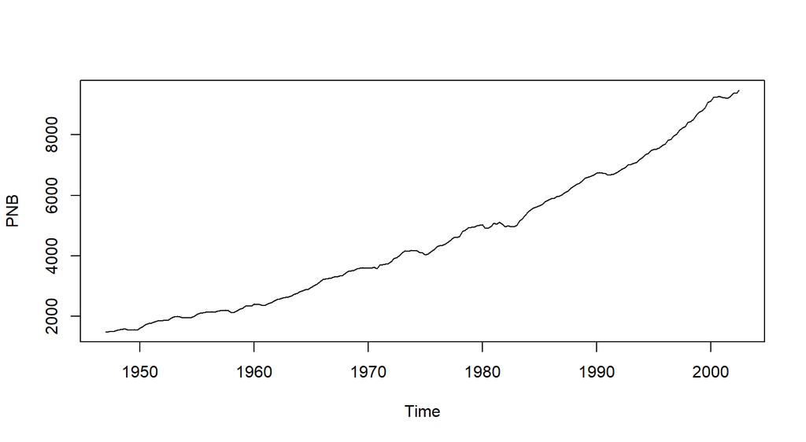

Figura 1: PNB trimestral norte-americano de 1947(1) a 2002(3).

### **Exemplo: Análise do PNB dos EUA**

A figura anterior mostra o gráfico dos dados, digamos, \(y_t\).

A forte tendência na série ofusca outras características e torna difícil ver qualquer outra variabilidade nos dados.

Apenas notamos alguns mergulhos periódicos na economia dos EUA.

Para dados como o PNB ou outros indicadores econômicos semelhantes, é de interesse a taxa de crescimento (porcentagem de mudança), em vez de valores reais.

A taxa de crescimento (primeira diferença dos logaritmos), \(x_t = \nabla \log(y_t)\), é plotada na figura seguinte e aparenta ser um processo estável.

### **Exemplo: Análise do PNB dos EUA**

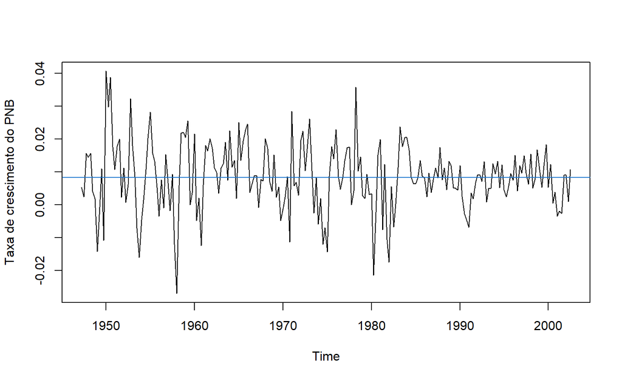

### **Exemplo: Análise do PNB dos EUA**

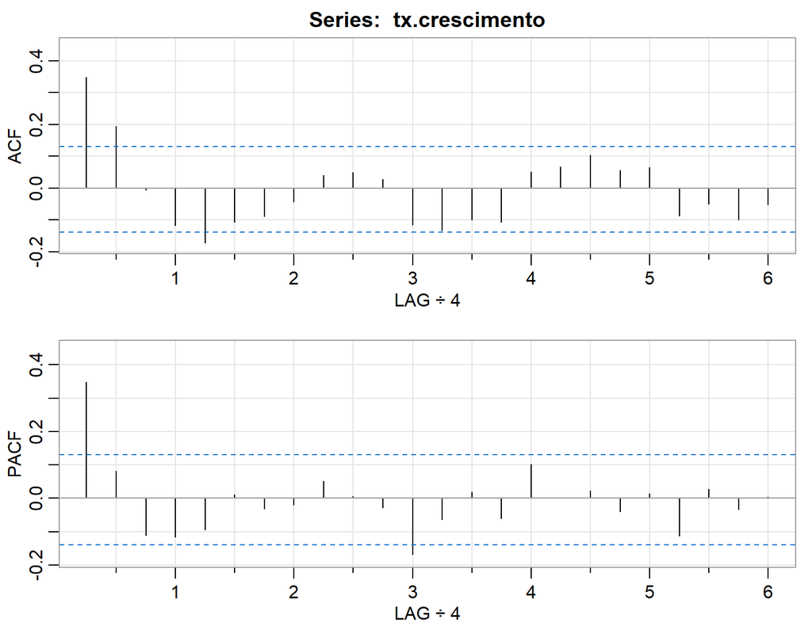

Figura 2: ACF e PACF da taxa de crescimento do PNB norte-americano. Defasagens em anos.

```
##      [,1] [,2]  [,3]  [,4]  [,5]  [,6]  [,7]  [,8] [,9] [,10] [,11] [,12] [,13]
## ACF  0.35 0.19 -0.01 -0.12 -0.17 -0.11 -0.09 -0.04 0.04  0.05  0.03 -0.12 -0.13
## PACF 0.35 0.08 -0.11 -0.12 -0.09  0.01 -0.03 -0.02 0.05  0.01 -0.03 -0.17 -0.06
##      [,14] [,15] [,16] [,17] [,18] [,19] [,20] [,21] [,22] [,23] [,24]
## ACF  -0.10 -0.11  0.05  0.07  0.10  0.06  0.07 -0.09 -0.05 -0.10 -0.05
## PACF  0.02 -0.06  0.10  0.00  0.02 -0.04  0.01 -0.11  0.03 -0.03  0.00
```

### **Exemplo: Análise do PNB dos EUA**

As ACF e PACF amostrais da taxa de crescimento estão representadas na Figura 2.

Isto sugere que a taxa de crescimento do PNB segue um processo MA(2), ou seja, o \(\log\)(PNB) segue um modelo ARIMA(0,1,2).

Podemos considerar também que a ACF decai bruscamente e a PACF está cortada na defasagem 1.

Desta vez, sugere-se um modelo AR(1) para a taxa de crescimento, ou seja, um ARIMA(1,1,0) para o \(\log\)(PNB).

### **Exemplo: Análise do PNB dos EUA**

Para ilustrar, vamos ajustar ambos os modelos:

ARIMA(0,1,2) e ARIMA(1,1,0)

A taxa de crescimento já é a 1ª diferença dos logaritmos.

Usando MLE para ajustar o modelo MA(2) para a taxa de crescimento, \(x_t\), no R:

```r
ma.gnb = sarima(tx.crescimento, 0,0,2, details=FALSE) # MA(2)
ma.gnb$ttable
```

```
##       Estimate     SE t.value p.value
## ma1     0.3028 0.0654  4.6272  0.0000
## ma2     0.2035 0.0644  3.1594  0.0018
## xmean   0.0083 0.0010  8.7178  0.0000
```

### **Exemplo: Análise do PNB dos EUA**

A coluna `SE` são os erros-padrão dos coeficientes estimados.

Todos os coeficientes são significativos, incluindo a constante.

Portanto, o modelo MA(2) estimado foi \[ \widehat{x}_t = 0.008+ 0.303 \widehat{w}_{t-1} + 0.203 \widehat{w}_{t-2} + \widehat{w}_t. \]

O modelo AR(1) é estimado com o comando

```r
ar.gnb = sarima(tx.crescimento, 1,0,0, details=FALSE) # AR(1)
ar.gnb$ttable
```

```
##       Estimate     SE t.value p.value
## ar1     0.3467 0.0627  5.5255       0
## xmean   0.0083 0.0010  8.5398       0
```

### **Exemplo: Análise do PNB dos EUA**

**Observação:** Modelos AR(\(p\)), em que a média, \(\mu\), de \(x_t\) é diferente de zero, são dados pela equação \[ x_t = \alpha + \phi_1 x_{t-1} + \phi_2 x_{t-2} + \cdots + \phi_p x_{t-p} + w_t, \] de modo que a constante \(\alpha\) passa a ser obtida da forma, \(\alpha = \mu(1 - \phi_1 - \cdots - \phi_p)\).

Visto isso, o modelo AR(1) estimado, com constante dada por \(\alpha = 0.008 (1-0.347) = 0.005\), é

\[ \widehat{x}_t = 0.005 + 0.347 x_{t-1} + \widehat{w}_t. \]

## Construindo modelos ARIMA

Próximo passo na construção de modelos ARIMA é **diagnóstico**.

Esta investigação inclui a análise dos resíduos, bem como a comparação de modelos ajustados.

Iniciamos o diagnóstico com o gráfico temporal dos resíduos, \(x_t - \widehat{x}_t^{t-1}\), ou dos resíduos padronizados \[ e_t = \frac{x_t - \widehat{x}_t^{t-1}}{\sqrt{\widehat{P}_t^{t-1}}}, \] em que \(\widehat{x}_t^{t-1}\) é o valor ajustado de \(x_t\) e \(\widehat{P}_t^{t-1}\) é a variância estimada do erro.

## Construindo modelos ARIMA

Se o modelo se ajusta bem aos dados, os resíduos padronizados, \(e_t\), devem se comportar como uma sequência com média 0 e variância 1.

A investigação da normalidade pode ser realizada visualmente observando o histograma dos resíduos.

Além disso, o gráfico **Q-Q *plot*** pode ajudar na identificação de desvios à normalidade.

Teste adicionais sobre a normalidade dos resíduos também podem ser aplicados; ver Johnson e Wichern (2002).

## Construindo modelos ARIMA

Podemos também inspecionar as autocorrelações amostrais dos resíduos, \(\widehat{\rho}_e(h)\), para identificar padrões ou valores muito altos.

Lembre-se que, para uma série ruído branco, as autocorrelações amostrais são independentes e normalmente distribuídas com médias 0 e variâncias \(1/n\).

Assim, uma boa prática para avaliar a estrutura de correlação dos resíduos é plotar \(\widehat{\rho}_e(h)\) versus \(h\) com os limites aproximados \(± 2/\sqrt{n}\).

O principal objetivo desta inspeção visual de \(\widehat{\rho}_e(h)\), é a detecção de independência.

## Construindo modelos ARIMA

Além deste gráfico, podemos realizar o **teste Ljung-Box** para avaliar a significância \(\widehat{\rho}_e(h)\).

A hipótese nula do teste Ljung-Box é a de que o modelo é adequado.

Logo, não devemos rejeitar a hipótese nula para as defasagens consideradas.

Veremos, a seguir, exemplos práticos de diagnósticos de modelos.

### **Exemplo: Diagnóstico para a tx. de crescimento PNB**

Vamos realizar a análise dos resíduos para o modelo MA(2) do Exemplo: Análise do PNB dos EUA; a análise dos resíduos do AR(1) é similar.

O diagnóstico dos modelos ajustados será realizado através da inspeção de:

- o gráfico dos resíduos padronizados;
- a ACF dos resíduos padronizados;
- o Q-Q plot dos resíduos padronizados; e
- os valores de \(p\) do teste Ljung-Box.

### **Exemplo: Diagnóstico para a tx. de crescimento PNB**

```r
aj.tx.cr = sarima(tx.crescimento, 0,0,2, details=FALSE) # IMA(0,1,2)
aj.tx.cr$ttable
```

```
##       Estimate     SE t.value p.value
## ma1     0.3028 0.0654  4.6272  0.0000
## ma2     0.2035 0.0644  3.1594  0.0018
## xmean   0.0083 0.0010  8.7178  0.0000
```

### **Exemplo: Diagnóstico para a tx. de crescimento PNB**

```r
sarima(tx.crescimento, 0,0,2, gg=TRUE, col=4)
```

[output not shown]

### **Exemplo: Diagnóstico para a tx. de crescimento PNB**

Observe indicações de *outliers*, i.e., presença de valores que ultrapassam 3 desvios-padrão.

A ACF dos resíduos padronizados não sugere violação de pressupostos do modelo.

O Q-Q *plot* sugere que a hipótese de normalidade é apropriada.

Pelo teste Ljung-Box, não há evidência para rejeitar a hipótese nula de que o modelo é adequado nas defasagens consideradas.

Estes gráficos de diagnósticos são saídas do comando `sarima`.

## Construindo modelos ARIMA

**Atenção!**

Temos que ter cuidado com a escolha do modelo.

No exemplo da taxa de crescimento do PNB dos EUA, tanto o MA(2), quanto o AR(1) parece ajustar bem os dados.

Podemos considerar também um AR(2), um MA(3), ou até mesmo uma combinação de ambos modelos anteriores e ajustar um ARMA(1,2) como melhores para a previsão da taxa de crescimento do PNB.

## Construindo modelos ARIMA

**Atenção!**

No entanto, temos de nos preocupar com o excesso de parâmetros (*overfitting*) do modelo; nem sempre o modelo “maior” é o melhor.

O excesso de parâmetros leva a estimadores menos precisos. Adicionando mais parâmetros pode ajustar melhor os dados, porém pode levar a previsões ruins.

## Construindo modelos ARIMA

A etapa final do ajuste do modelo é a seleção do modelo.

*Diante do fato dos dois modelos se ajustarem bem à taxa de crescimento do PNB norte-americano, qual modelo adotar para obter as previsões?*

Ou seja, devemos decidir qual modelo vamos adotar para realizar a previsão.

Existem dezenas de métodos para a seleção de modelo. No entanto, os mais populares passam pelos critérios AIC, AICc e BIC.

- AIC - Critério de informação de Akaike;
- AICc - Critério de informação de Akaike corrigido;
- BIC - Critério de informação bayesiano.

O menor valor para estes critérios indica o melhor modelo.

### **Exemplo: Escolha do modelo para o PNB**

Lembre-se que dois modelos, AR(1) e MA(2), se ajustam bem à taxa de crescimento do PNB norte-americano.

Para escolher o modelo final, comparamos o AIC, o AICc e o BIC.

Esses valores também são saídas da função `sarima` executada em exemplo anterior, exibida novamente abaixo.

```r
# Modelo MA(2)
sarima(tx.crescimento, 0,0,2, details = FALSE)$AIC
sarima(tx.crescimento, 0,0,2, details = FALSE)$AICc
sarima(tx.crescimento, 0,0,2, details = FALSE)$BIC
# Modelo AR(1)
sarima(tx.crescimento, 1,0,0, details = FALSE)$AIC
sarima(tx.crescimento, 1,0,0, details = FALSE)$AICc
sarima(tx.crescimento, 1,0,0, details = FALSE)$BIC
```

### **Exemplo: Escolha do modelo para o PNB**

Os valores fornecidos pelos dois modelos foram:

| Modelo | AIC | AICc | BIC |
| --- | --- | --- | --- |
| MA(2) | -6.450 | -6.450 | -6.389 |
| AR(1) | -6.447 | -6.447 | -6.401 |

Os critérios AIC e AICc selecionam o ajuste MA(2), enquanto que o BIC indica o modelo AR(1).

Geralmente, o BIC tende a selecionar um modelo da ordem menor do que o AIC ou o AICc.

Em casos assim, é razoável optar pelo AR(1), pois os modelos autoregressivos puros são mais fáceis de trabalhar.

## Modelos ARIMA sazonais

Vamos introduzir aqui as modificações feitas no modelo ARIMA para lidar o comportamento sazonal e não-estacionário de séries temporais.

Muitas vezes, a dependência do passado tende a ocorrer com maior intensidade nos múltiplos de algumas defasagens.

Por exemplo, com dados econômicos mensais, há um forte componente anual que ocorre em defasagens múltiplas de \(s = 12\), devido às conexões de atividades ao longo do ano.

Os dados tomados trimestralmente tendem a exibir ciclos repetitivos anuais em \(s = 4\) trimestres.

## Modelos ARIMA sazonais

Fenômenos naturais, como a temperatura, umidade relativa do ar, também têm componentes fortes relacionados às estações.

Assim, a variabilidade natural de muitos processos físicos, biológicos e econômicos tende a apresentar flutuações sazonais.

Devido a isso, é apropriado introduzir polinômios autorregressivos e de média móvel que incorporem defasagens sazonais.

## Modelos ARIMA sazonais

O modelo autoregressivo de média móvel sazonal puro, ARMA\((P,Q)_s\), assume a forma \[ \Phi_P(B^s) x_t = \Theta_Q(B^s) w_t, \] em que os operadores \[ \Phi_P (B^s) = 1 - \Phi_1 B^s - \Phi_2 B^{2s} - \cdots - \Phi_P B^{Ps} \] e \[ \Theta_Q (B^s) = 1 + \Theta_1 B^s + \Theta_2 B^{2s} + \cdots + \Theta_Q B^{Qs} \] são o **operador autorregressivo sazonal** e o **operador média móvel sazonal** de ordens \(P\) e \(Q\), respectivamente, com período sazonal \(s\).

## Modelos ARIMA sazonais

Para entender melhor a expressão do modelo ARMA\((P,Q)_s\), vamos considerar uma série autorregressiva sazonal de primeira ordem, ou seja AR\((1)_s\), com \(s=12\), escrita como \[ \begin{aligned} (1 - \Phi B^{12}) x_t &= w_t\\[1mm] x_t - \Phi B^{12} x_t &= w_t\\[1mm] x_t &= \Phi x_{t-12} + w_t. \end{aligned} \]

- Lembrem-se do operador translação para o passado \(B^k x_t = x_{t-k}\) definido antes.
- A figura seguinte mostra uma série de 3 anos simulada do AR(1) sazonal com \(\Phi = 0.9\), e as respectivas funções ACF e PACF.

## Modelos ARIMA sazonais

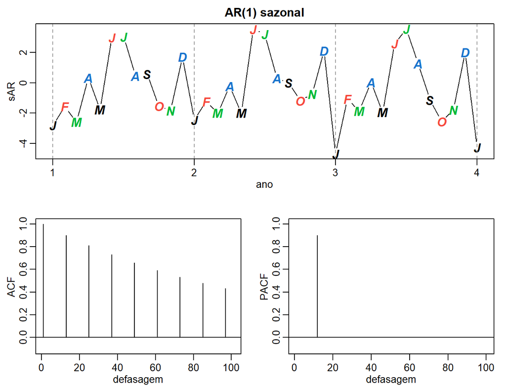

## Modelos ARIMA sazonais

- Já um processo autorregressivo de média móvel sazonal de primeira ordem com representação mensal, ARMA\((1,1)_s\), é escrito na forma \[ (1 - \Phi B^{12}) x_t = (1 + \Theta B^{12}) w_t \] ou \[ x_t = \Phi x_{t-12} + w_t + \Theta w_{t-12}. \]
- Este modelo representa a série \(x_t\) em termos de defasagens do período sazonal anual \(s = 12\) meses.
- A estimação do modelo e a previsão se dá como no caso da defasagem unitária já apresentada para os modelos ARMA(\(p,q\)).

## Modelos ARIMA sazonais

- Em geral, podemos combinar os operadores sazonais e não-sazonais em um modelo autorregressivo de média móvel sazonal, denotado por ARMA\((p,q)\times(P,Q)_s\) e escrever \[ \Phi_P (B^s) \Phi (B) x_t = \Theta_Q (B^s) \Theta (B) w_t \] como o modelo geral.

### **Exemplo: ARMA(0,1)(1,0)\(_{12}\) simulado**

- Consideremos um modelo ARMA(0,1)(1,0)\(_{12}\)

\[ \begin{aligned} (1 - \Phi B^{12}) x_t &= w_t + \theta w_{t-1}\\[1mm] x_t - \Phi x_{t-12} &= w_t + \theta w_{t-1}\\[1mm] x_t &= \Phi x_{t-12} + w_t + \theta w_{t-1}, \end{aligned} \] e vamos gerar uma série com \(\Phi = .8\) e \(\theta = -.5\).

- A ACF e a PACF para esta série simulada, são apresentadas na figura a seguir.

### **Exemplo: ARMA(0,1)(1,0)\(_{12}\) simulado**

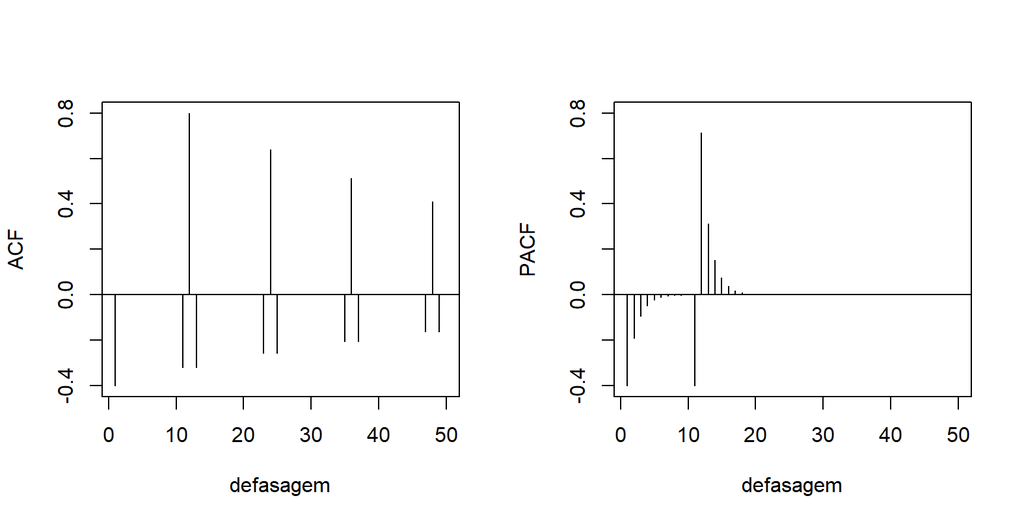

Figura 3: ACF e PACF para o modelo ARMA sazonal \(x_t = .8 x_{t-12} + w_t - .5 w_{t-1}\) simulado.

### **Exemplo: ARMA(0,1)(1,0)\(_{12}\) simulado**

- Este padrão na ACF é típico de série temporal sazonal.
- Por exemplo, as temperaturas mensais ao longo do ano; todo janeiro \(\sim\) a mesma, todo fevereiro \(\sim\) a mesma \(\dots\)
- Neste caso, podemos pensar na temperatura mensal \(x_t\) como

\[ x_t = S_t + w_t, \] em que \(S_t\) é o componente sazonal que varia pouco de um ano para o outro, como o passeio aleatório, \[ S_t = S_{t-12} + v_t. \] \(w_t\) e \(v_t\) são processos ruído branco não correlacionados.

### **Exemplo: ARMA(0,1)(1,0)\(_{12}\) simulado**

- É comum que, para dados com este comportamento, a ACF amostral apresente valores grandes em defasagens \(h = 12k\), para \(k = 1, 2,\dots\) que decaem lentamente, como na Figura 3.
- Se subtrairmos o efeito de anos consecutivos, chegamos a \[ (1 - B^{12}) x_t = x_t - x_{t-12} = v_t + w_t - w_{t-12} \] que é um modelo é MA\((1)_{12}\) estacionário, e sua ACF terá um pico somente na defasagem 12.
- Em geral, a diferenciação sazonal é indicada quando a ACF decai lentamente em múltiplos de \(s\), mas a queda é insignificante entre os períodos.

## Modelos ARIMA sazonais

- Vamos agora definir a diferença sazonal de ordem \(D\) como \[ \nabla_s^D x_t = (1 - B^s)^D x_t, \] com \(D = 1, 2,\dots\)
- Tipicamente \(D = 1\) é suficiente para obter a estacionaridade sazonal.
- Incorporar essas ideias em um modelo geral leva à seguinte definição.

## Modelos ARIMA sazonais

**Definição:** O **modelo SARIMA**, é dado por \[ \Phi_P (B^s) \phi(B) \nabla_s^D \nabla^d x_t = \delta + \Theta_Q (B^s) \theta (B) w_t. \] e é denotado por ARIMA\((p,d,q)(P,D,Q)_s\).

- Os componentes autorregressivo e de média móvel simples, ordens \(p\) e \(q\), são dados por \(\phi(B)\) e \(\theta(B)\), respectivamente.
- Os componentes autorregressivo e de média móvel sazonais, ordens \(P\) e \(Q\), são dados por \(\Phi_P(B^s)\) e \(\Theta_Q(B^s)\), respectivamente.
- As diferenças simples e sazonal são \(\nabla^d = (1 - B)^d\) e \(\nabla_s^D = (1 - B^s)^D\), respectivamente.

## Modelos ARIMA sazonais

- Selecionar o modelo ARIMA\((p,d,q)(P,D,Q)_s\) apropriado para uma série temporal pode ser uma tarefa complexa.
- Geralmente, seguimos os passos:
1. Encontrar operadores de diferença que produzem uma série aproximadamente estacionária;
2. Encontrar os candidatos ARMA ou ARMA\(_s\) para ajustar a série residual resultante;
3. Avaliar a ACF e a PACF dos resíduos; os picos que aparecem nestas funções podem ser eliminados ajustando um componente autorregressivo ou de média móvel.
4. Por fim, se o modelo é satisfatório, as técnicas diagnósticas discutidas antes ainda se aplicam.

### **Exemplo: Passageiros aéreos**

- Consideremos os dados disponíveis no R `AirPassengers`, que são os totais mensais de passageiros em uma companhia aérea, 1949 a 1960.
- A empresa queria prever a demanda futura antes de encomendar novos aviões e realizar o treinamento da tripulação.
- Os dados originais e algumas transformações são mostrados na figura a seguir com os comandos no R:

```r
x = AirPassengers     # original
lx = log(x)           # log
dlx = diff(lx)        # diferença dos log
ddlx = diff(dlx, 12)  # dif. sazonal dos log, s=12
plot.ts(cbind(x,lx,dlx,ddlx), yax.flip=TRUE, main="")
```

### **Exemplo: Passageiros aéreos**

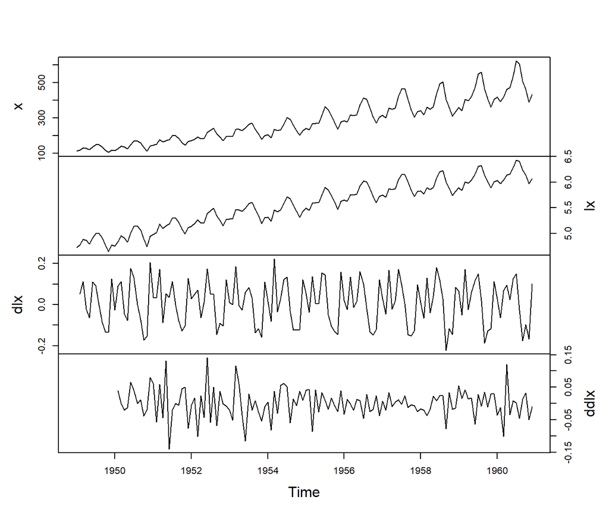

### **Exemplo: Passageiros aéreos**

\[{\rm ddlx} = \nabla_{12} \nabla \log x_t.\]

### **Exemplo: Passageiros aéreos**

- A série transformada `ddlx` aparenta ser estacionária e, então, vamos ajustar um modelo a ela.
- A ACF e a PACF amostrais de `ddlx` para 50 defasagens são mostradas a seguir.

```r
library(astsa)
acf2(ddlx, 50)
```

### **Exemplo: Passageiros aéreos**

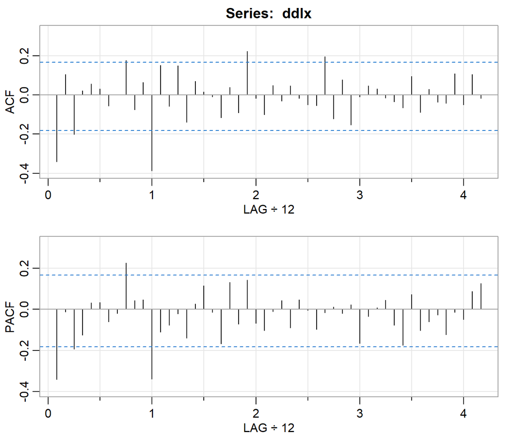

```
##       [,1]  [,2]  [,3]  [,4] [,5] [,6]  [,7]  [,8] [,9] [,10] [,11] [,12] [,13]
## ACF  -0.34  0.11 -0.20  0.02 0.06 0.03 -0.06  0.00 0.18 -0.08  0.06 -0.39  0.15
## PACF -0.34 -0.01 -0.19 -0.13 0.03 0.03 -0.06 -0.02 0.23  0.04  0.05 -0.34 -0.11
##      [,14] [,15] [,16] [,17] [,18] [,19] [,20] [,21] [,22] [,23] [,24] [,25]
## ACF  -0.06  0.15 -0.14  0.07  0.02 -0.01 -0.12  0.04 -0.09  0.22 -0.02  -0.1
## PACF -0.08 -0.02 -0.14  0.03  0.11 -0.01 -0.17  0.13 -0.07  0.14 -0.07  -0.1
##      [,26] [,27] [,28] [,29] [,30] [,31] [,32] [,33] [,34] [,35] [,36] [,37]
## ACF   0.05 -0.03  0.05 -0.02 -0.05 -0.05  0.20 -0.12  0.08 -0.15 -0.01  0.05
## PACF -0.01  0.04 -0.09  0.05  0.00 -0.10 -0.02  0.01 -0.02  0.02 -0.16 -0.03
##      [,38] [,39] [,40] [,41] [,42] [,43] [,44] [,45] [,46] [,47] [,48] [,49]
## ACF   0.03 -0.02 -0.03 -0.07  0.10 -0.09  0.03 -0.04 -0.04  0.11 -0.05  0.11
## PACF  0.01  0.05 -0.08 -0.17  0.07 -0.10 -0.06 -0.03 -0.12 -0.01 -0.05  0.09
##      [,50]
## ACF  -0.02
## PACF  0.13
```

### **Exemplo: Passageiros aéreos**

*Sazonal*: A ACF e a PACF dão indício de haver alta correlação na defasagem \(1s\), com \(s = 12\).

- Estes resultados sugerem um SARMA(0,1), \(P = 0, Q = 1\), com \(s = 12\).

*Não-Sazonal*: A ACF e a PACF tem pontos fora dos intervalos para defasagens menores. Podemos pensar num ARMA(1,1).

- Assim, dadas as características da ACF e da PACF e as transformações tomadas, testamos um ARIMA(1,1,1)(0,1,1)\(_{12}\).
- Como vamos tomar a primeira diferença, \(d=1\), e a primeira diferença sazonal, \(D=1\), vamos ajustar o modelo à série `lx`.

### **Exemplo: Passageiros aéreos**

```r
sarima1.lx = sarima(lx, 1,1,1, 0,1,1, 12, details=FALSE)
sarima1.lx$ttable
```

```
##      Estimate     SE t.value p.value
## ar1    0.1960 0.2475  0.7921  0.4298
## ma1   -0.5784 0.2132 -2.7127  0.0076
## sma1  -0.5643 0.0747 -7.5544  0.0000
```

- Notem que o parâmetro AR não é significativo, então, vamos tentar um modelo ARIMA(0,1,1)(0,1,1)\(_{12}\):

```r
sarima2.lx = sarima(lx, 0,1,1, 0,1,1, 12, details=FALSE)
```

```
##      Estimate     SE t.value p.value
## ma1   -0.4018 0.0896 -4.4825       0
## sma1  -0.5569 0.0731 -7.6190       0
```

### **Exemplo: Passageiros aéreos**

- Diagnóstico do modelo final, ARIMA(0,1,1)(0,1,1)\(_{12}\):

```
## $fit
##
## Call:
## arima(x = xdata, order = c(p, d, q), seasonal = list(order = c(P, D, Q), period = S),
##     include.mean = !no.constant, transform.pars = trans, fixed = fixed, optim.control = list(trace = trc,
##         REPORT = 1, reltol = tol))
##
## Coefficients:
##           ma1     sma1
##       -0.4018  -0.5569
## s.e.   0.0896   0.0731
##
## sigma^2 estimated as 0.001348:  log likelihood = 244.7,  aic = -483.4
##
## $degrees_of_freedom
## [1] 129
##
## $ttable
##      Estimate     SE t.value p.value
## ma1   -0.4018 0.0896 -4.4825       0
## sma1  -0.5569 0.0731 -7.6190       0
##
## $AIC
## [1] -3.690069
##
## $AICc
## [1] -3.689354
##
## $BIC
## [1] -3.624225
```

### **Exemplo: Passageiros aéreos**

```r
prev.log.Air = sarima.for(lx, n.ahead=12, 0,1,1, 0,1,1, 12)$pred
prev.log.Air
```

- Os resultados estão a seguir.

### **Exemplo: Passageiros aéreos**

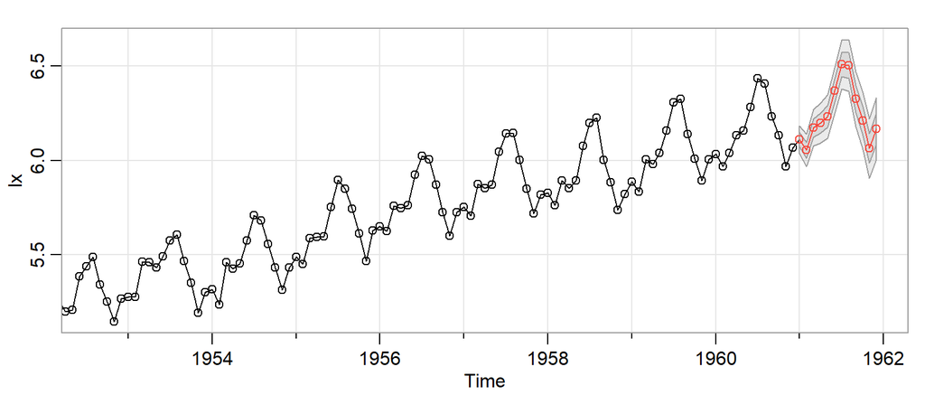

```
##           Jan      Feb      Mar      Apr      May      Jun      Jul      Aug
## 1961 6.110186 6.053775 6.171715 6.199300 6.232556 6.368779 6.507294 6.502906
##           Sep      Oct      Nov      Dec
## 1961 6.324698 6.209008 6.063487 6.168025
```

### **Exemplo: Passageiros aéreos**

- De posse das previsões do \(\log x_t\), aplicamos o anti-log (neste exemplo, \(\exp x_t\)) e obtemos as previsões de \(x_t\).

```r
prev.Air = exp(prev.log.Air)
prev.Air
```

```
##           Jan      Feb      Mar      Apr      May      Jun      Jul      Aug
## 1961 450.4224 425.7172 479.0068 492.4045 509.0550 583.3449 670.0108 667.0776
##           Sep      Oct      Nov      Dec
## 1961 558.1894 497.2078 429.8720 477.2426
```

- E plotamos o gráfico com estas previsões.

```r
ts.plot(AirPassengers, prev.Air, col=1:2, ylab="nº de passageiros")
lines(prev.Air, type="p", col=2)
```

### **Exemplo: Passageiros aéreos**

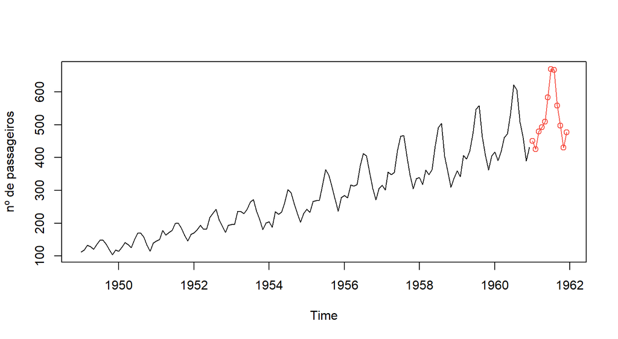

### **Exemplo: Índice de Produção Federal**

- É de interesse identificar um modelo da classe Box-Jenkins para uma dada série temporal e então produzir previsões com base no modelo ajustado.
- Neste exemplo, vamos considerar a aplicação dessa metodologia ao Índice de Produção Federal, uma série mensal de 1948 a 1978.
- Estes dados estão disponíveis no R, no pacote `astsa`.

```r
library(astsa)
data(prodn)
```

### **Exemplo: Índice de Produção Federal**

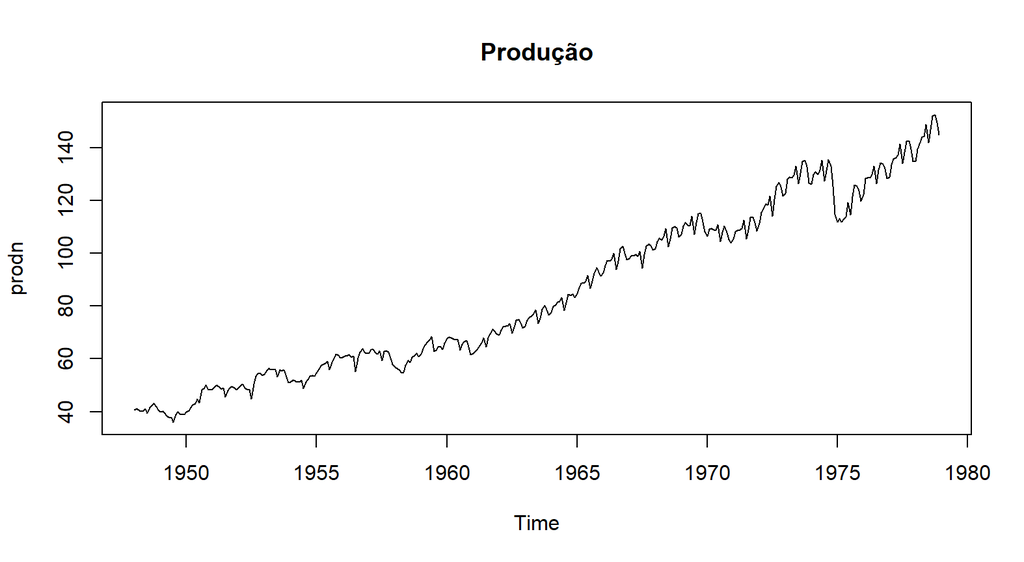

### **Exemplo: Índice de Produção Federal**

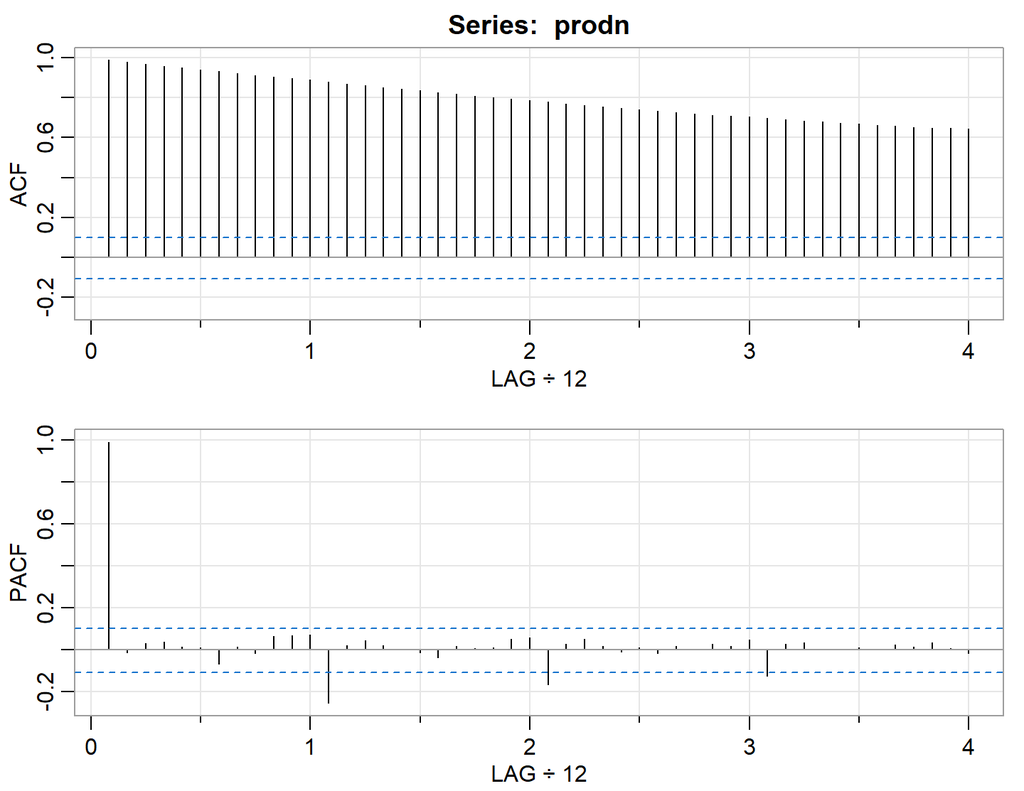

```
##      [,1]  [,2] [,3] [,4] [,5] [,6]  [,7] [,8]  [,9] [,10] [,11] [,12] [,13]
## ACF  0.99  0.98 0.97 0.96 0.95 0.94  0.93 0.92  0.91  0.90  0.90  0.89  0.88
## PACF 0.99 -0.01 0.03 0.04 0.01 0.01 -0.07 0.01 -0.02  0.06  0.07  0.07 -0.25
##      [,14] [,15] [,16] [,17] [,18] [,19] [,20] [,21] [,22] [,23] [,24] [,25]
## ACF   0.87  0.86  0.85  0.84  0.84  0.83  0.82  0.81  0.80  0.79  0.79  0.78
## PACF  0.02  0.04  0.02  0.00 -0.01 -0.04  0.02  0.01  0.01  0.05  0.06 -0.16
##      [,26] [,27] [,28] [,29] [,30] [,31] [,32] [,33] [,34] [,35] [,36] [,37]
## ACF   0.77  0.76  0.75  0.75  0.74  0.73  0.73  0.72  0.71  0.71  0.71  0.70
## PACF  0.03  0.05  0.02 -0.01  0.01 -0.02  0.02  0.00  0.03  0.02  0.05 -0.13
##      [,38] [,39] [,40] [,41] [,42] [,43] [,44] [,45] [,46] [,47] [,48]
## ACF   0.69  0.68  0.68  0.67  0.67  0.66  0.66  0.65  0.65  0.65  0.64
## PACF  0.03  0.04  0.00  0.00  0.01  0.00  0.03  0.01  0.03  0.01 -0.02
```

### **Exemplo: Índice de Produção Federal**

- Notem a tendência nos dados, a queda lenta na ACF e a PACF quase 1 na primeira defasagem indicando comportamento não-estacionário.

Seguindo o procedimento recomendado, tomamos a primeira diferença,

\[ \nabla x_t = x_t - x_{t-1} \] e a ACF e a PACF da primeira diferença são mostrados na figura a seguir.

### **Exemplo: Índice de Produção Federal**

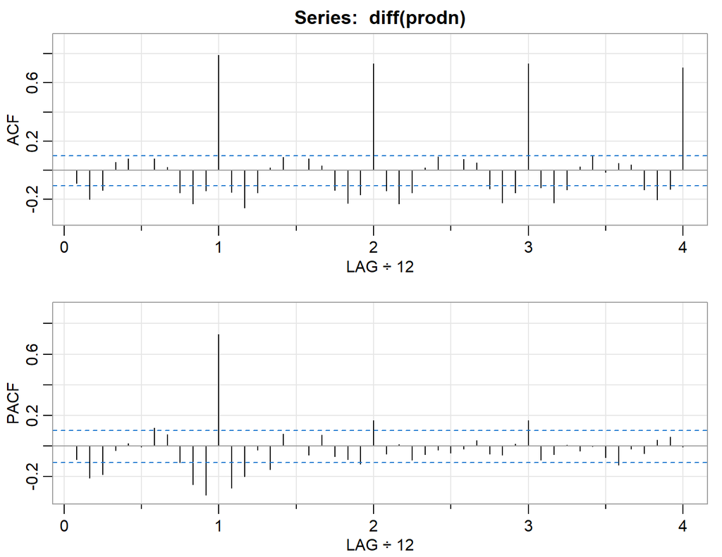

```
##       [,1]  [,2]  [,3]  [,4] [,5]  [,6] [,7] [,8]  [,9] [,10] [,11] [,12] [,13]
## ACF  -0.09 -0.20 -0.14  0.05 0.08  0.00 0.08 0.02 -0.15 -0.23 -0.14  0.79 -0.15
## PACF -0.09 -0.21 -0.19 -0.03 0.02 -0.01 0.12 0.07 -0.11 -0.25 -0.32  0.73 -0.27
##      [,14] [,15] [,16] [,17] [,18] [,19] [,20] [,21] [,22] [,23] [,24] [,25]
## ACF  -0.26 -0.15  0.02  0.09     0  0.08  0.03 -0.14 -0.23 -0.17  0.73 -0.14
## PACF -0.20 -0.03 -0.15  0.08     0 -0.06  0.07 -0.07 -0.09 -0.12  0.17 -0.05
##      [,26] [,27] [,28] [,29] [,30] [,31] [,32] [,33] [,34] [,35] [,36] [,37]
## ACF  -0.23 -0.15  0.02  0.09  0.00  0.08  0.05 -0.13 -0.22 -0.15  0.73 -0.12
## PACF  0.01 -0.09 -0.05 -0.03 -0.05 -0.02  0.04 -0.05 -0.06  0.01  0.17 -0.09
##      [,38] [,39] [,40] [,41] [,42] [,43] [,44] [,45] [,46] [,47] [,48]
## ACF  -0.22 -0.13  0.02   0.1 -0.01  0.05  0.04 -0.13 -0.20 -0.13   0.7
## PACF -0.06  0.01 -0.03   0.0 -0.08 -0.12 -0.02 -0.05  0.04  0.06   0.0
```

### **Exemplo: Índice de Produção Federal**

- Observem os picos na ACF nas defasagens sazonais \(h = 1s, 2s, 3s, 4s\), onde \(s = 12\) (i.e., \(h = 12, 24, 36, 48\)) com decaimento relativamente lento sugerindo uma diferença sazonal.
- Aplicamos, então, a diferença sazonal e obtemos a diferença da produção diferenciada, digamos,

\[ \nabla_{12} \nabla x_t = (1 - B^{12}) (1 - B) x_t. \] com ACF e PACF mostradas na figura seguinte.

### **Exemplo: Índice de Produção Federal**

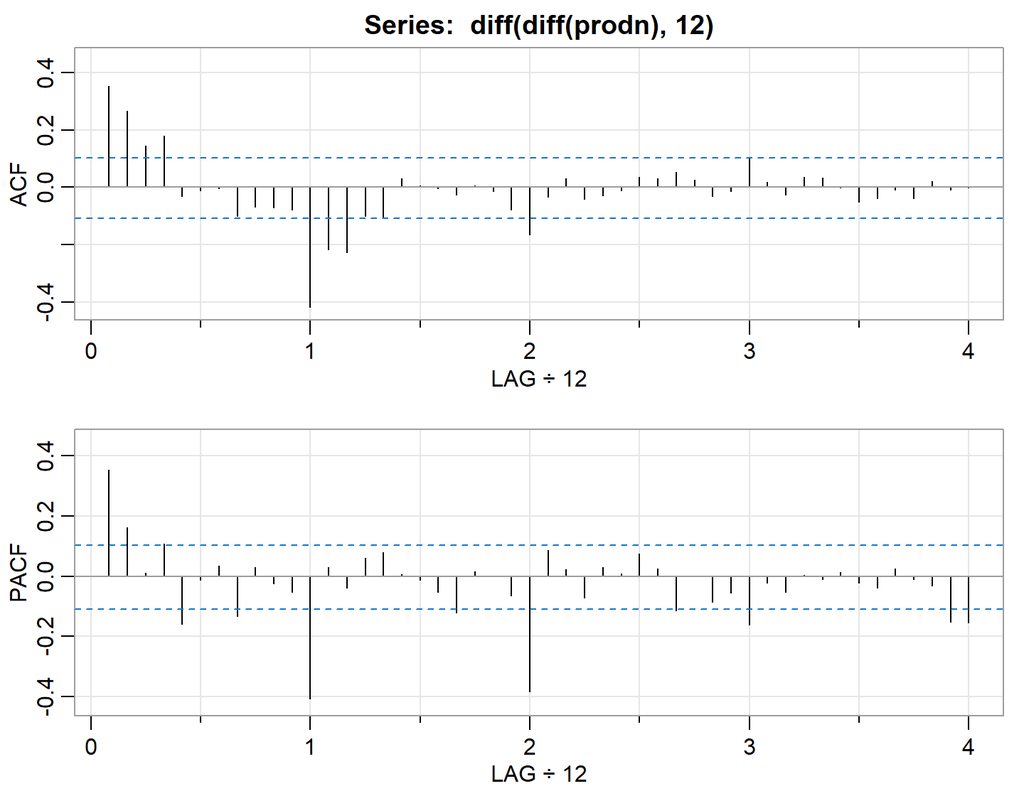

```
##      [,1] [,2] [,3] [,4]  [,5]  [,6] [,7]  [,8]  [,9] [,10] [,11] [,12] [,13]
## ACF  0.35 0.27 0.14 0.18 -0.03 -0.01 0.00 -0.10 -0.07 -0.07 -0.08 -0.42 -0.22
## PACF 0.35 0.16 0.01 0.11 -0.16 -0.01 0.03 -0.13  0.03 -0.03 -0.05 -0.41  0.03
##      [,14] [,15] [,16] [,17] [,18] [,19] [,20] [,21] [,22] [,23] [,24] [,25]
## ACF  -0.23 -0.10 -0.11  0.03  0.00  0.00 -0.03  0.01 -0.01 -0.08 -0.17 -0.03
## PACF -0.04  0.06  0.08  0.01 -0.01 -0.05 -0.12  0.02  0.00 -0.07 -0.38  0.09
##      [,26] [,27] [,28] [,29] [,30] [,31] [,32] [,33] [,34] [,35] [,36] [,37]
## ACF   0.03 -0.04 -0.03 -0.01  0.04  0.03  0.05  0.03 -0.03 -0.01  0.10  0.02
## PACF  0.02 -0.07  0.03  0.01  0.07  0.03 -0.11  0.00 -0.09 -0.06 -0.16 -0.02
##      [,38] [,39] [,40] [,41] [,42] [,43] [,44] [,45] [,46] [,47] [,48]
## ACF  -0.03  0.04  0.03  0.00 -0.05 -0.04 -0.01 -0.04  0.02 -0.01  0.00
## PACF -0.05  0.00 -0.01  0.01 -0.02 -0.04  0.03 -0.01 -0.03 -0.15 -0.16
```

### **Exemplo: Índice de Produção Federal**

- Por sugestão, podemos adotar:
  1. um SMA de ordem \(Q = 1\),
  2. um SMA de ordem \(Q = 3\), ou
  3. um SARMA de ordens \(P = 2\) (devido aos dois picos na PACF) e \(Q = 1\).
- Em seguida, inspecionando a ACF e a PACF dentro dos períodos sazonais, defasagens \(h = 1,. . . , 11\), parece que:
  - tanto a ACF quanto a PACF apresentam decaimento nos valores, ou
  - a PACF é cortada na defasagem 2.

### **Exemplo: Índice de Produção Federal**

- Com base na tabela de identificação da ordem do modelo, estas características sugerem modelos com \(p>0\) e \(q>0\) para os componentes não-sazonais; digamos

1.1. \(p=1, q=1\) ou  
1.2. \(p=2, q=0\).

- Por simplicidade, vamos nos concentrar no modelo sugerido em (2) e (1.2); ARIMA(2,1,0)(0,1,3)\(_{12}\).

```r
model.prod.fit.2b = sarima(prodn, 2,1,0, 0,1,3, 12, details=FALSE)
prod.fit.2b = model.prod.fit.2b$ttable
```

### **Exemplo: Índice de Produção Federal**

- O modelo ARIMA(2,1,0)(0,1,3)\(_{12}\) ajustado foi:

```
##      Estimate     SE  t.value p.value
## ar1    0.3038 0.0526   5.7708  0.0000
## ar2    0.1077 0.0538   2.0030  0.0459
## sma1  -0.7393 0.0539 -13.7175  0.0000
## sma2  -0.1445 0.0653  -2.2119  0.0276
## sma3   0.2815 0.0526   5.3475  0.0000
```

\[ \begin{aligned} (1 - 0.30 B - 0.11 B^2&) \nabla_{12} \nabla \widehat{x}_t =\\ &(1 -0.74 B^{12} -0.14 B^{24} + 0.28 B^{36}) \widehat{w}_t, \end{aligned} \] com todos os parâmetros estatisticamente significantes.

### **Exemplo: Índice de Produção Federal**

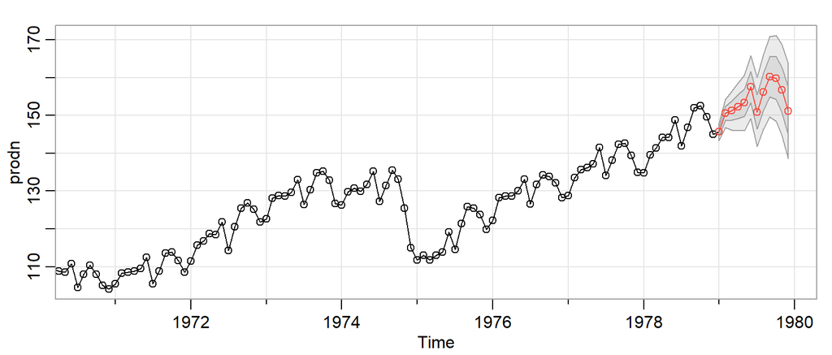

```
##           Jan      Feb      Mar      Apr      May      Jun      Jul      Aug
## 1979 145.6808 150.5469 151.2870 152.3131 153.3714 157.5532 150.9487 156.2781
##           Sep      Oct      Nov      Dec
## 1979 160.2958 159.8744 156.7729 151.1447
```

### **Exemplo: Índice de Produção Federal**

- O seguinte código `R` foi usado para executar a análise deste exemplo.

```r
library(astsa)
data(prodn)
plot(prodn, main="Produção")
acf2(prodn, 48)
acf2(diff(prodn), 48)
acf2(diff(diff(prodn), 12), 48)
## modelo sugerido em (ii) e (b)
sarima(prodn, 2,1,0, 0,1,3, 12, details=FALSE)$ttable
## Previsão pelo modelo final
sarima.for(prodn,12, 2,1,0, 0,1,3, 12)
```

## Cereja do bolo

[figure not shown]

## Referências

## Referências

1. Bollerslev, T. Generalized autoregressive conditional heteroskedasticity. *Journal of econometrics*, 31(3), 307-327, 1986.
2. Box, G. E., e Jenkins, G. M. *Time Series Models for Forecasting and Control*. San Francisco, 1970.
3. Box, G. E., Jenkins, G. M. e Reinsel, G. C. *Forecasting and Control. Time Series Analysis*. 1994.
4. Cleveland, W. S. Robust locally weighted regression and smoothing scatterplots. *J. American Statistical Association* 74, 829–836, 1979.
5. Engle, R. Autoregressive Conditional Heteroscedasticity with Estimates of the Variance of United Kingdom Inflation. *Econometrica*, 1982.
6. Gouriéroux, C. *ARCH models and financial applications*. Springer Science & Business Media, 2012.
7. Hyndman, R.J., & Athanasopoulos, G. (2018) Forecasting: principles and practice, 2nd edition, OTexts: Melbourne, Australia. Disponível em: https://otexts.com/fpp2/. Acessado em: 25/10/2022.
8. Hyndman, R. and Athanasopoulos, G. Forecasting: principles and practice. 3rd. ed. Melbourne, Australia: OTexts, 2021. Disponível em: https://otexts.com/fpp3/. Acessado em: 25/10/2022.

## Referências

1. Johnson, R. A. e Wichern, D. W. *Applied multivariate statistical analysis* (Vol. 5, No. 8). Upper Saddle River, NJ: Prentice hall, 2002.
2. Morettin, P. A., e Toloi, C. *Análise de séries temporais*. Blucher, 2006.
3. Nielsen, A. Análise Prática de Séries Temporais: Predição com Estatística e Aprendizado de Máquina (2021). Ed. Alta Books. 1ª edição.
4. Schuster, A. On the periodicities of sunspots. *Phil. Trans. R. Soc., Ser. A*, 206, 69-100, 1906.

## Perguntas

[figure not shown]

## Agradecimento

[figure not shown]

Acesse: https://github.com/rladiessalvador

Siga: @rladiessalvador